# Take-home Exercise 1

In this take-home Exercise, I will explore the relationships between different features in participants dataset.

LIU Zhenglin https://example.com/norajones (SMU SCIS)https://example.com/spacelysprokets  
2022-04-24

# 1. Overview

In this take-home exercise, I will explore the relationships between different features in participants dataset, and try to find the which kind of people have higher joviality.

# 2. Getting Started

The code chunk below is used to install and load the required packages onto RStudio.

```r
packages = c('tidyverse')

for (p in packages){
  if(!require(p, character.only = T)){
    install.package(p)
  }
  library(p, character.only = T)
}

library(patchwork)
```

# 3. Importing Data

The code chunk below import *Participants.csv* from data folder into R by using [`read_csv()`](https://readr.tidyverse.org/reference/read_delim.html) of [**readr** package](https://readr.tidyverse.org/index.html) and save it as an tibble data frame called *participants*.

```r
participants <- read_csv("data/Participants.csv")
glimpse(participants)
```

```
Rows: 1,011
Columns: 7
$ participantId  <dbl> 0, 1, 2, 3, 4, 5, 6, 7, 8, 9, 10, 11, 12, 13,~
$ householdSize  <dbl> 3, 3, 3, 3, 3, 3, 3, 3, 3, 3, 3, 3, 3, 3, 3, ~
$ haveKids       <lgl> TRUE, TRUE, TRUE, TRUE, TRUE, TRUE, TRUE, TRU~
$ age            <dbl> 36, 25, 35, 21, 43, 32, 26, 27, 20, 35, 48, 2~
$ educationLevel <chr> "HighSchoolOrCollege", "HighSchoolOrCollege",~
$ interestGroup  <chr> "H", "B", "A", "I", "H", "D", "I", "A", "G", ~
$ joviality      <dbl> 0.001626703, 0.328086500, 0.393469590, 0.1380~
```

# 4. Analysis

From the information of this data set above, we can see that there are 7 different columns in this data set, but participant Id column which presents different participant, has over 1000 unique values. I will not include this feature in my analysis since is not a meaningful feature for participants. As for the rest features, plot the distribution for each one as a preparation for further analysis.

### 4.1 Distribution of features

The code chunk below plot a bar chart by using [`geom_bar()`](https://ggplot2.tidyverse.org/reference/geom_bar.html) by [**ggplot2 package**](https://ggplot2.tidyverse.org/index.html).

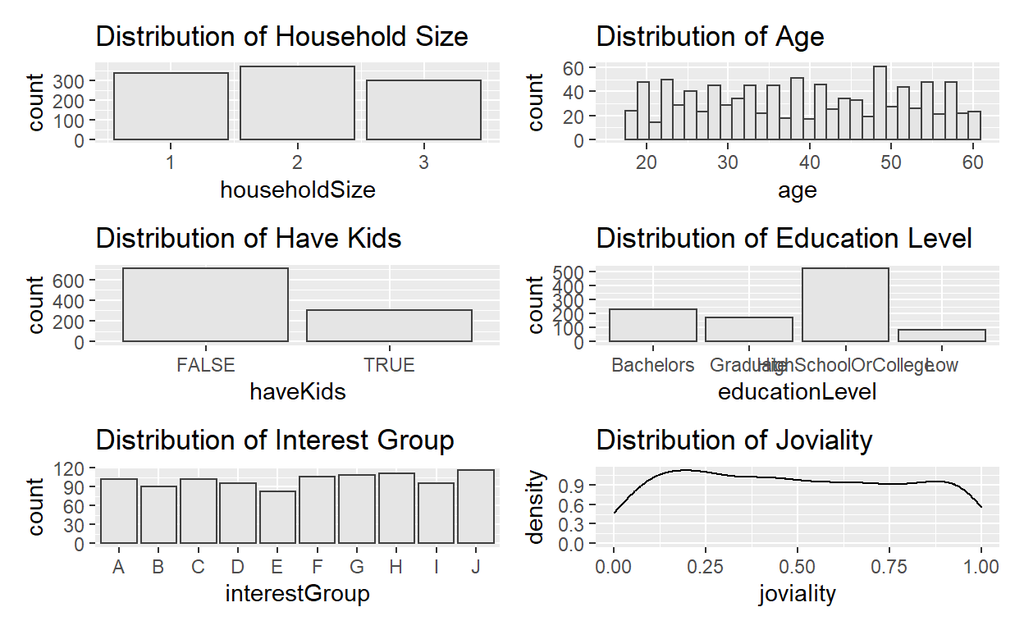

```r
p_householdsize <- ggplot(data = participants,
       aes(x = householdSize))+
  geom_bar(color="grey25",
           fill="grey90") +
  ggtitle("Distribution of Household Size")

p_havekids <- ggplot(data=participants,
             aes(x = haveKids)) +
  geom_bar(color="grey25",
           fill="grey90") +
  ggtitle("Distribution of Have Kids")

p_age <- ggplot(data=participants,
             aes(x = age)) +
  geom_histogram(boundary = 100,
                 color="grey25",
                 fill="grey90") +
  coord_cartesian(xlim=c(16, 61)) +
  ggtitle("Distribution of Age")

p_edu <- ggplot(data=participants,
             aes(x = educationLevel)) +
  geom_bar(boundary = 100,
                 color="grey25",
                 fill="grey90") +
  ggtitle("Distribution of Education Level")

p_interest <- ggplot(data=participants,
             aes(x = interestGroup)) +
  geom_bar(boundary = 100,
                 color="grey25",
                 fill="grey90") +
  ggtitle("Distribution of Interest Group")

p_joviality<- ggplot(data=participants,
             aes(x = joviality)) +
  geom_density() +
  ggtitle("Distribution of Joviality")

(p_householdsize/p_havekids/p_interest)|(p_age/p_edu/p_joviality)
```

In the participants, most of them don’t have kids and have high school or college education level. There is no a dominant interest in these participants, and the joviality distribution is quite uniform.

### 4.2 Data Processing

From the distributions figure of features above, we can see that the age feature has too many unique value. We can combine them into different age group for our analysis.

```r
participants_age <- participants %>%
  mutate(age_group = cut(age, breaks = c(17,25,35,45,55,60)))
```

### 4.3 Feature Relationship Exploration

From the distribution figures and the features name, I want to see the relationship between some features.

Relationship between household size and have kids

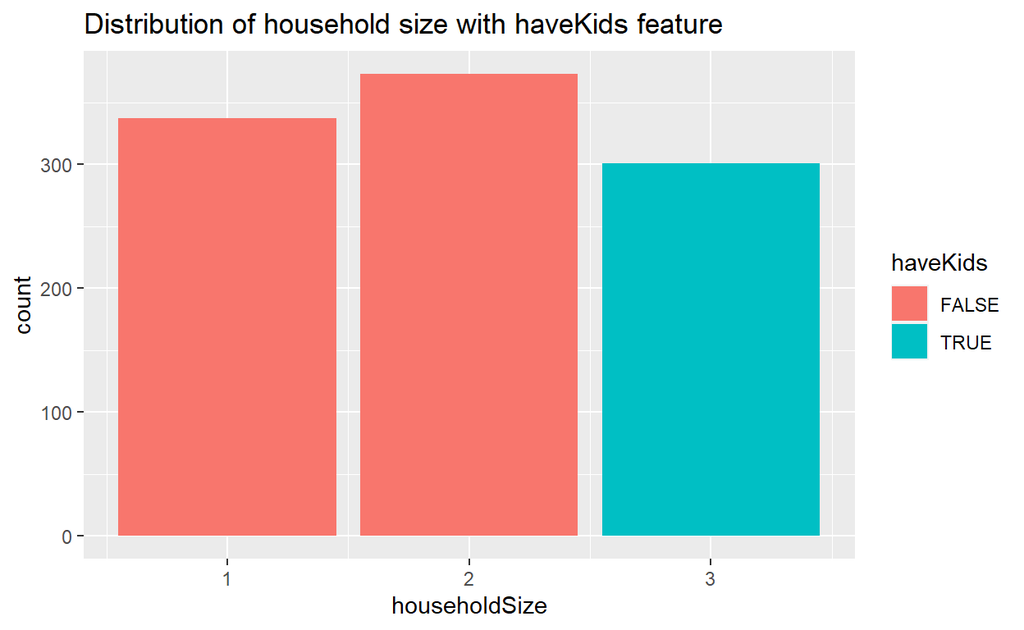

```r
ggplot(data = participants_age,
       aes(x = householdSize, fill = haveKids))+
  geom_bar()+
  ggtitle("Distribution of household size with haveKids feature")
```

From the chart we can have a conclusion, the participants whose household size equals to 3, all of them have kids.

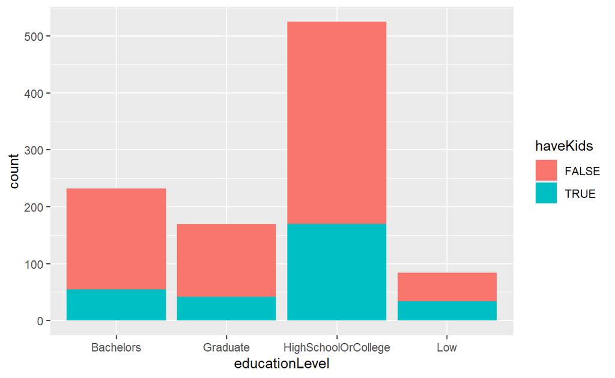

```r
ggplot(data = participants,
       aes(x = educationLevel, fill = haveKids))+
  geom_bar()
```

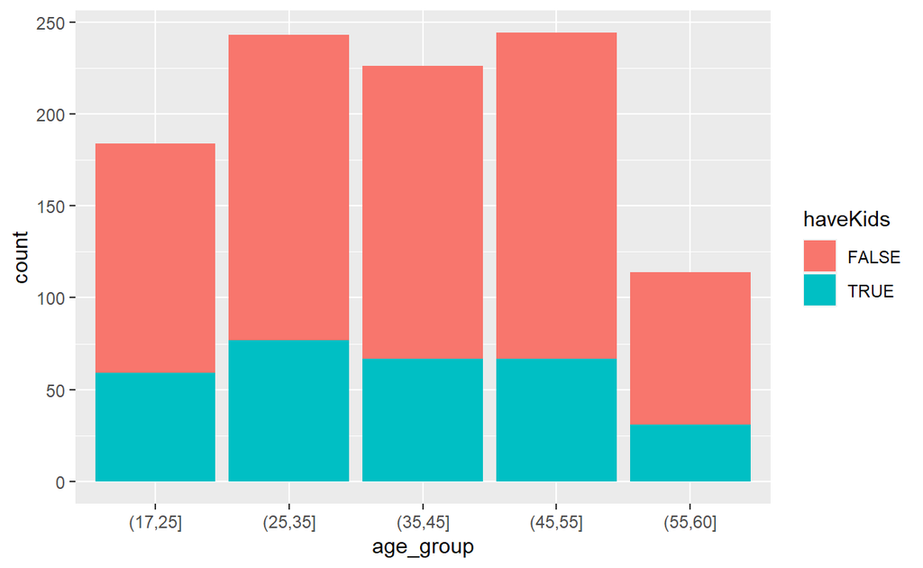

```r
ggplot(data = participants_age,
       aes(x = age_group, fill = haveKids))+
  geom_bar()
```

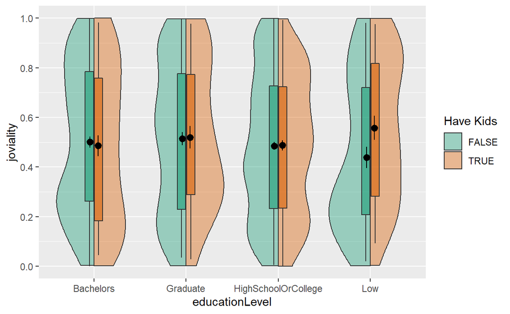

```r
ggplot(participants_age, aes(x = educationLevel, y = joviality, fill = haveKids)) +
  introdataviz::geom_split_violin(alpha = .4, trim = FALSE) +
  geom_boxplot(width = .2, alpha = .6, fatten = NULL, show.legend = FALSE) +
  stat_summary(fun.data = "mean_se", geom = "pointrange", show.legend = F,
               position = position_dodge(.175)) +
  scale_y_continuous(breaks = seq(0, 1, 0.2),
                     limits = c(0, 1)) +
  scale_fill_brewer(palette = "Dark2", name = "Have Kids")
```